# Notebook

```python
from google.colab import drive
drive.mount('/content/drive')
```

```python
import pandas as pd
import matplotlib.pyplot as plt
import seaborn as sns

import warnings
warnings.filterwarnings("ignore")
```

How Happy are you in your Current Position with the following?

(Salary): How happy are you with your salary in your current position?

(Work/Life Balance): How satisfied are you with your work-life balance in your current position?

(Coworkers): How do you feel about your coworkers in your current role?

(Management): How happy are you with the management in your current position?

(Upward Mobility): Are you satisfied with the upward mobility opportunities in your current position?

(Learning New Things): How satisfied are you with your opportunities to learn new things in your role?

```python
# Reading in the saved data
file_path = '/content/drive/MyDrive/biweekly assignment/Project_data.xlsx'
df = pd.read_excel(file_path)

# Display the first few rows to confirm successful reading
df.head()
```

|  | Job_Title | Career_Switch | Salary_USD | Industry | Fav_Language | Happiness_Salary | Happiness_WorkLife | Happiness_Coworkers | Happiness_Management | Happiness_Mobility | Happiness_Learning | Difficulty_Breaking_In | Job_Priority | Gender | Age | Country | Education_Level | Ethnicity |
| --- | --- | --- | --- | --- | --- | --- | --- | --- | --- | --- | --- | --- | --- | --- | --- | --- | --- | --- |
| 0 | Data Engineer | No | 66k-85k | Finance | Python | 2 | 1 | 1 | 1 | 3 | 7 | Easy | Remote Work | Female | 28 | United States | Masters | Asian or Asian American |
| 1 | Data Analyst | Yes | 66k-85k | Tech | Python | 6 | 6 | 6 | 6 | 5 | 6 | Difficult | Other (Please Specify):Currently very happy wi... | Female | 24 | United States | Bachelors | Hispanic or Latino |
| 2 | Other (Please Specify):Business Analyst | No | 41k-65k | Other (Please Specify):Third Party Logistics | C/C++ | 3 | 6 | 7 | 7 | 1 | 3 | Very Difficult | Better Salary | Male | 29 | United States | Bachelors | White or Caucasian |
| 3 | Data Analyst | No | 66k-85k | Telecommunication | Python | 4 | 6 | 4 | 5 | 4 | 4 | Neither easy nor difficult | Better Salary | Male | 24 | United States | Masters | White or Caucasian |
| 4 | Data Analyst | Yes | 41k-65k | Tech | Python | 5 | 6 | 7 | 7 | 7 | 6 | Difficult | Better Salary | Male | 25 | United States | Bachelors | Asian or Asian American |

```python
df.isna().sum()
```

|  | 0 |
| --- | --- |
| Job_Title | 0 |
| Career_Switch | 0 |
| Salary_USD | 0 |
| Industry | 0 |
| Fav_Language | 0 |
| Happiness_Salary | 0 |
| Happiness_WorkLife | 0 |
| Happiness_Coworkers | 0 |
| Happiness_Management | 0 |
| Happiness_Mobility | 0 |
| Happiness_Learning | 0 |
| Difficulty_Breaking_In | 0 |
| Job_Priority | 0 |
| Gender | 0 |
| Age | 0 |
| Country | 0 |
| Education_Level | 0 |
| Ethnicity | 0 |

**dtype:** int64

dtype: int64 If missing values are found this could potentially bias analysis if the missing values are not handled appropriately."

For example, if missing values are related to specific characteristics, it might lead to an inaccurate representation of the data." It's crucial to consider the mechanism behind missing data (e.g., random or systematic) and address them using suitable imputation or removal techniques."

2. **Descriptive** **Statistics**

```python
#lets seperate the happiness columns
happiness_columns=df.iloc[:,5:10]
for col in happiness_columns:
    print(f"/Descriptive Statistics {col}")
    print(f"The mean of {col}",df[col].mean())
    print(f"The median of {col}",df[col].median())
    print(f"The mode of {col}",df[col].mode(),"\t")
    print("="*50)
```

```
/Descriptive Statistics Happiness_Salary
The mean of Happiness_Salary 5.27542372881356
The median of Happiness_Salary 5.0
The mode of Happiness_Salary 0    3
Name: Happiness_Salary, dtype: int64
==================================================
/Descriptive Statistics Happiness_WorkLife
The mean of Happiness_WorkLife 6.593220338983051
The median of Happiness_WorkLife 7.0
The mode of Happiness_WorkLife 0     6
1    10
Name: Happiness_WorkLife, dtype: int64
==================================================
/Descriptive Statistics Happiness_Coworkers
The mean of Happiness_Coworkers 6.686440677966102
The median of Happiness_Coworkers 7.0
The mode of Happiness_Coworkers 0    10
Name: Happiness_Coworkers, dtype: int64
==================================================
/Descriptive Statistics Happiness_Management
The mean of Happiness_Management 6.088983050847458
The median of Happiness_Management 6.0
The mode of Happiness_Management 0    5
1    7
Name: Happiness_Management, dtype: int64
==================================================
/Descriptive Statistics Happiness_Mobility
The mean of Happiness_Mobility 5.385593220338983
The median of Happiness_Mobility 5.0
The mode of Happiness_Mobility 0    5
Name: Happiness_Mobility, dtype: int64
==================================================
```

**we can see here each** **happiness** **column** **have** **different** **mean**,**mode** **and** **median** **values**

```python
# Group by gender and calculate mean, median, and mode for happiness columns
for col in happiness_columns:
  print(f"\nDescriptive Statistics for {col} grouped by Gender:")
  print(df.groupby('Gender')[col].agg(['mean', 'median',]))
  print(f"The mode for {col} based on",df.groupby('Gender')[col].agg(pd.Series.mode))
  print("=" * 50)
```

```
Descriptive Statistics for Happiness_Salary grouped by Gender:
            mean  median
Gender
Female  5.208333     5.0
Male    5.304878     5.0
The mode for Happiness_Salary based on Gender
Female    4
Male      3
Name: Happiness_Salary, dtype: int64
==================================================

Descriptive Statistics for Happiness_WorkLife grouped by Gender:
           mean  median
Gender
Female  6.75000     7.0
Male    6.52439     6.0
The mode for Happiness_WorkLife based on Gender
Female    10
Male       6
Name: Happiness_WorkLife, dtype: int64
==================================================

Descriptive Statistics for Happiness_Coworkers grouped by Gender:
            mean  median
Gender
Female  6.569444     7.0
Male    6.737805     7.0
The mode for Happiness_Coworkers based on Gender
Female    10
Male       5
Name: Happiness_Coworkers, dtype: int64
==================================================

Descriptive Statistics for Happiness_Management grouped by Gender:
            mean  median
Gender
Female  5.847222     6.0
Male    6.195122     6.0
The mode for Happiness_Management based on Gender
Female    5
Male      6
Name: Happiness_Management, dtype: int64
==================================================

Descriptive Statistics for Happiness_Mobility grouped by Gender:
            mean  median
Gender
Female  5.291667     5.5
Male    5.426829     5.0
The mode for Happiness_Mobility based on Gender
Female    6
Male      5
Name: Happiness_Mobility, dtype: int64
==================================================
```

**Grouped Analysis**

```python
# Group data by 'Job Title' and calculate the average 'Happiness Salary'
average_happiness_salary_by_job = df.groupby('Job_Title')['Happiness_Salary'].mean()
average_happiness_salary_by_job

# Investigate differences between men and women in similar roles
gender_job_happiness = df.groupby(['Job_Title', 'Gender'])['Happiness_Salary'].mean().unstack()
gender_job_happiness

# You can further analyze this by calculating the difference in average happiness salary
# between men and women for each job title.
gender_job_happiness['Difference'] = gender_job_happiness['Female'] - gender_job_happiness['Male']
gender_job_happiness.sort_values(by='Difference', ascending=False).head(6)
#only 7 job_titles have the difference in the men and women
```

| Gender Job_Title | Female | Male | Difference |
| --- | --- | --- | --- |
| Other (Please Specify):Business Analyst | 8.00 | 5.500000 | 2.500000 |
| Data Analyst | 5.48 | 5.276786 | 0.203214 |
| Data Scientist | 7.00 | 7.200000 | -0.200000 |
| Data Engineer | 4.00 | 4.461538 | -0.461538 |
| Other (Please Specify):Analytics Engineer | 5.00 | 5.500000 | -0.500000 |
| Database Developer | 4.00 | 6.000000 | -2.000000 |

from the above table it is clear that females working as a data analyst and business analyst are more happy with their job roles and salary then the males

```python
# Calculate the mean "Happiness WorkLife" score by "Country"
mean_happiness_worklife_by_country = df.groupby('Country')['Happiness_WorkLife'].mean()
mean_happiness_worklife_by_country.sort_values(ascending=False)
```

| Country | Happiness_WorkLife |
| --- | --- |
| United States | 6.682292 |
| Canada | 6.590909 |
| United Kingdom | 5.818182 |

**dtype:** float64

**From the above output we can say that Canada and United States are the best countries to work . These countries have highest happiness with work life with mean value 6.68 and 6.59**

```python
def categorize_response(response):
    if 'Other (Please Specify):' in response:
        # Extract the specified value after "Other (Please Specify):"
        specified_value = response.split(': ')[-1].strip()
        # If the value is "SQL", categorize it separately
        if specified_value.lower() == 'sql':
            return 'SQL'
        else:
            # Group other specified responses into "Others"
            return 'Others'

    if 'Other:' in response:
        others_value = response.split(':', 1)[-1].strip().lower()
        if others_value.lower() == 'sql':
            return 'SQL'
        else:
            return 'Others'
    if 'Other' in response:
        others_value = response.split(':', 1)[-1].strip().lower()
        if others_value.lower() == 'sql':
            return 'SQL'
        else:
            return 'Others'
    else:
        # Retain the original response if not in the "Other (Please Specify)" format
        return response

# Apply the function to the Response column
df['Fav_Language'] = df['Fav_Language'].apply(categorize_response)

# Output the resulting DataFrame
df['Fav_Language'].value_counts()
```

| Fav_Language | count |
| --- | --- |
| Python | 137 |
| R | 46 |
| Others | 29 |
| SQL | 18 |
| C/C++ | 3 |
| JavaScript | 2 |
| Java | 1 |

**dtype:** int64

```python
# Function to categorize responses
def categorize_response(response):
    if 'Other (Please Specify):' in response:
        others_value = response.split(':', 1)[-1].strip().lower()
        # Categorize common roles
        return  'Others'
    if 'Other (Please Specify)' in response:
             return 'Others'
     # General "Others" category for unspecified roles
    else:
        return response  # Retain original response if not "Other (Please Specify)"

# Apply categorization function
df['New_Jobtitle'] = df['Job_Title'].apply(categorize_response)

# Aggregate counts by processed response
#aggregated_data = df.groupby('Processed_Response', as_index=False)['Count'].sum()

# Output results
df['New_Jobtitle'].value_counts()
```

| New_Jobtitle | count |
| --- | --- |
| Data Analyst | 162 |
| Others | 44 |
| Data Engineer | 16 |
| Data Scientist | 12 |
| Database Developer | 2 |

**dtype:** int64

```python
df.head()
```

|  | Job_Title | Career_Switch | Salary_USD | Industry | Fav_Language | Happiness_Salary | Happiness_WorkLife | Happiness_Coworkers | Happiness_Management | Happiness_Mobility | Happiness_Learning | Difficulty_Breaking_In | Job_Priority | Gender | Age | Country | Education_Level | Ethnicity | New_Jobtitle |
| --- | --- | --- | --- | --- | --- | --- | --- | --- | --- | --- | --- | --- | --- | --- | --- | --- | --- | --- | --- |
| 0 | Data Engineer | No | 66k-85k | Finance | Python | 2 | 1 | 1 | 1 | 3 | 7 | Easy | Remote Work | Female | 28 | United States | Masters | Asian or Asian American | Data Engineer |
| 1 | Data Analyst | Yes | 66k-85k | Tech | Python | 6 | 6 | 6 | 6 | 5 | 6 | Difficult | Other (Please Specify):Currently very happy wi... | Female | 24 | United States | Bachelors | Hispanic or Latino | Data Analyst |
| 2 | Other (Please Specify):Business Analyst | No | 41k-65k | Other (Please Specify):Third Party Logistics | C/C++ | 3 | 6 | 7 | 7 | 1 | 3 | Very Difficult | Better Salary | Male | 29 | United States | Bachelors | White or Caucasian | Others |
| 3 | Data Analyst | No | 66k-85k | Telecommunication | Python | 4 | 6 | 4 | 5 | 4 | 4 | Neither easy nor difficult | Better Salary | Male | 24 | United States | Masters | White or Caucasian | Data Analyst |
| 4 | Data Analyst | Yes | 41k-65k | Tech | Python | 5 | 6 | 7 | 7 | 7 | 6 | Difficult | Better Salary | Male | 25 | United States | Bachelors | Asian or Asian American | Data Analyst |

**Univariate Analysis**

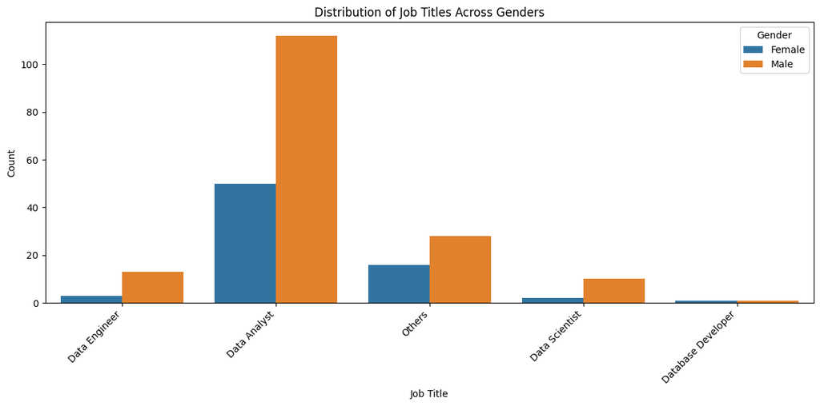

| New_Jobtitle | Gender | count |
| --- | --- | --- |
| Data Analyst | Male | 112 |
|  | Female | 50 |
| Data Engineer | Male | 13 |
|  | Female | 3 |
| Data Scientist | Male | 10 |
|  | Female | 2 |
| Database Developer | Female | 1 |
|  | Male | 1 |
| Others | Male | 28 |
|  | Female | 16 |

**dtype:** int64

```python
#Distribution of Jobtitle B/W men and women
plt.figure(figsize=(12, 6))
sns.countplot(x='New_Jobtitle', data=df, hue='Gender')
plt.title('Distribution of Job Titles Across Genders')
plt.xlabel('Job Title')
plt.ylabel('Count')
plt.xticks(rotation=45, ha='right')
plt.tight_layout()
plt.show()

Popular_jobs=df.groupby('New_Jobtitle')['Gender'].value_counts().head(10)
Popular_jobs
```

**Data Analyst , Data Engineer and Data Scientist job roles are widely choosen by males then females . Male domination is more in this job roles , approximately 50% males dominating females . We can see this clearly from the above graph**.

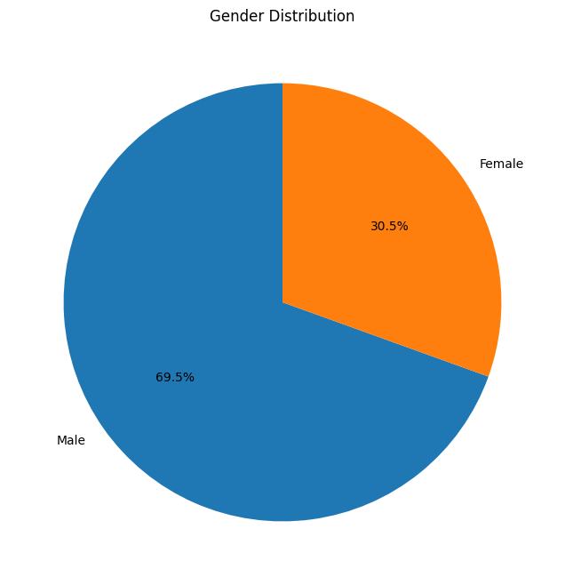

```python
# Gender Distribution
gender_counts = df['Gender'].value_counts()

# Create a pie chart
plt.figure(figsize=(8, 8))
plt.pie(gender_counts, labels=gender_counts.index, autopct='%1.1f%%', startangle=90)
plt.title('Gender Distribution')
plt.show()
```

**The pie chart discribes percentage of gender distribution among female and male . It is clear that male distribution is more than the female (69.5%)**

```python
#Programming Language Popularity:
top_3langs=df.Fav_Language.value_counts().head(3)
```

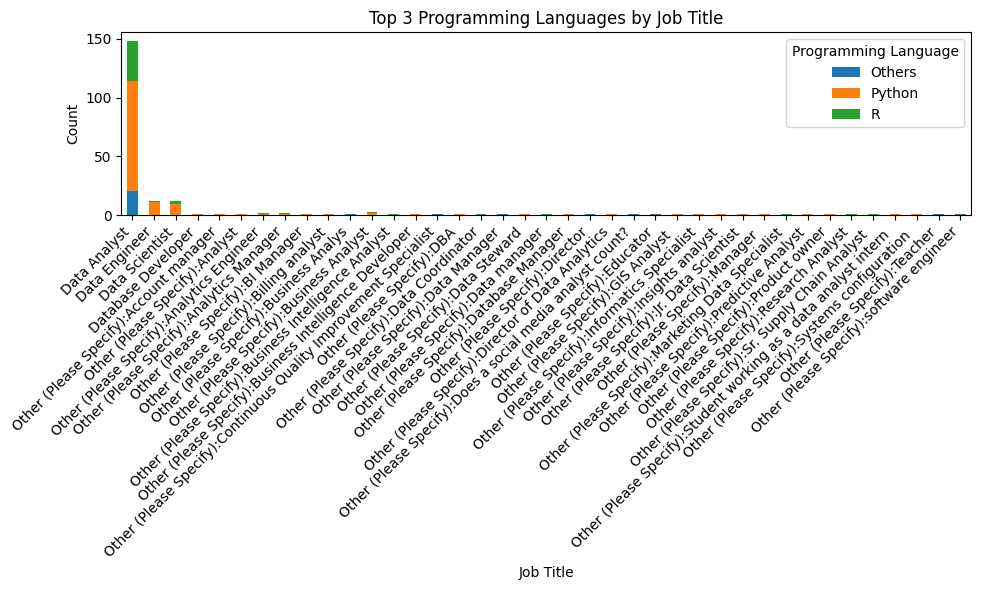

```python
# Add 'top_3langs' column to the DataFrame based on 'Fav_Language'
df['top_3langs'] = df['Fav_Language'].apply(lambda x: x if x in top_3langs.index else None)

# Now, group by the newly added 'top_3langs' column along with 'Job_Title'
grouped_df = df.groupby(['Job_Title', 'top_3langs'])['top_3langs'].count().unstack()

grouped_df.plot(kind='bar', stacked=True, figsize=(10, 6))
plt.title('Top 3 Programming Languages by Job Title')
plt.xlabel('Job Title')
plt.ylabel('Count')
plt.xticks(rotation=45, ha='right')  # Rotate x-axis labels for better readability
plt.legend(title='Programming Language')
plt.tight_layout()  # Adjust layout to prevent labels from overlapping
plt.show()
```

**Those who are working as Data Analyst uses top 3 programming languages then others.**

**Bivariate Analysis**

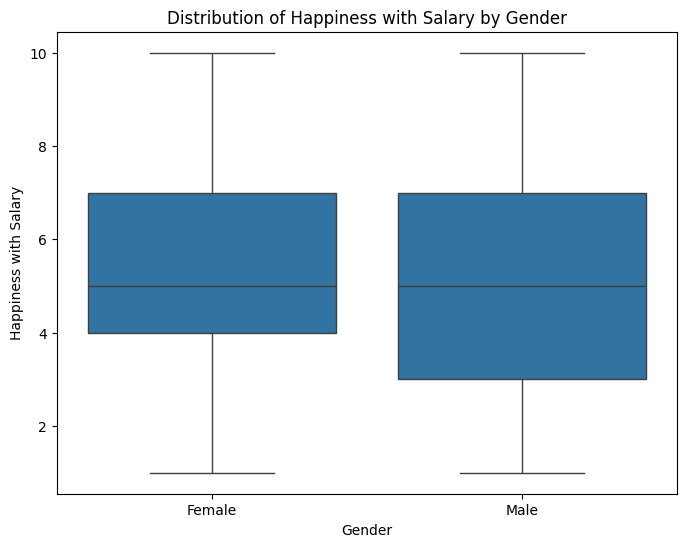

```
Median Happiness with Salary for Men: 5.0
Median Happiness with Salary for Women: 5.0
```

```python
# Box plots for Happiness Salary by gender
plt.figure(figsize=(8, 6))
sns.boxplot(x='Gender', y='Happiness_Salary', data=df)
plt.title('Distribution of Happiness with Salary by Gender')
plt.xlabel('Gender')
plt.ylabel('Happiness with Salary')
plt.show()

#The median happiness with salary for men and women
median_salary_happiness_men = df[df['Gender'] == 'Male']['Happiness_Salary'].median()
median_salary_happiness_women = df[df['Gender'] == 'Female']['Happiness_Salary'].median()

print(f"Median Happiness with Salary for Men: {median_salary_happiness_men}")
print(f"Median Happiness with Salary for Women: {median_salary_happiness_women}")
```

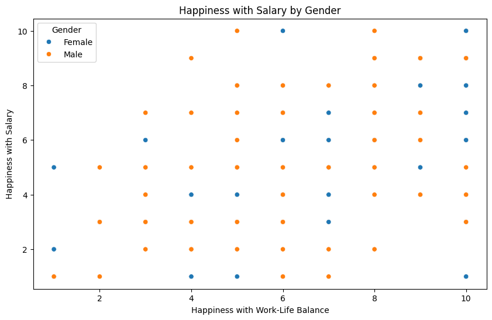

```python
# Relation b/w happiness with salary and happiness with work-life balance
import seaborn as sns

plt.figure(figsize=(10, 6))
sns.scatterplot(x='Happiness_WorkLife', y='Happiness_Salary', data=df, hue='Gender')
plt.title('Happiness with Salary by Gender')
plt.xlabel('Happiness with Work-Life Balance')
plt.ylabel('Happiness with Salary')
plt.legend(title='Gender')
plt.show()
```

**There is a positive relationship between Happiness with Work-life Balance and Happiness with Salary for both male and female**

[figure not shown]

```python
#e distribution of salary ranges between men and women across different countries.
sns.barplot(x='Country',y='Salary_USD',data=df,hue='Gender')
plt.title('Happiness with Salary by Gender')
plt.xlabel('Happiness with Work-Life Balance')
plt.ylabel('Happiness with Salary')
plt.legend(title='Gender')
plt.show()
```

```python
def categorize_response(response):
    if 'Other (Please Specify):' in response:
        others_value = response.split(':', 1)[-1].strip().lower()
        # Categorize common roles
        return  'Others'
    if 'Other (Please Specify)' in response:
             return 'Others'
     # General "Others" category for unspecified roles
    else:
        return response  # Retain original response if not "Other (Please Specify)"

# Apply categorization function
df['Job_Priority'] = df['Job_Priority'].apply(categorize_response)

# Aggregate counts by processed response
#aggregated_data = df.groupby('Processed_Response', as_index=False)['Count'].sum()

# Output results
df['Job_Priority'].value_counts()
```

| Job_Priority | count |
| --- | --- |
| Better Salary | 117 |
| Remote Work | 46 |
| Good Work/Life Balance | 32 |
| Good Culture | 26 |
| Others | 15 |

**dtype:** int64

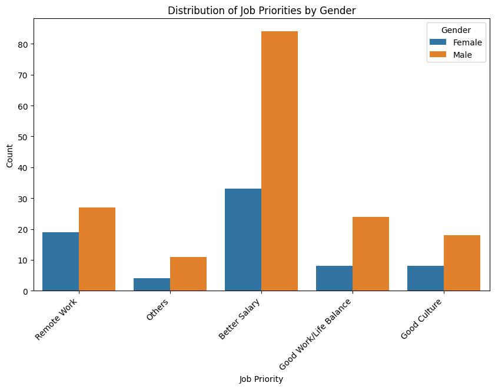

```python
# Compare job priorities between men and women
plt.figure(figsize=(10, 6))
sns.countplot(x='Job_Priority', data=df, hue='Gender')
plt.title('Distribution of Job Priorities by Gender')
plt.xlabel('Job Priority')
plt.ylabel('Count')
plt.xticks(rotation=45, ha='right')
plt.show()
```

**According to the barchart the better salary have the more job priorities fallowed by remote work. Moreover the male employeers are have highest job priorities.**

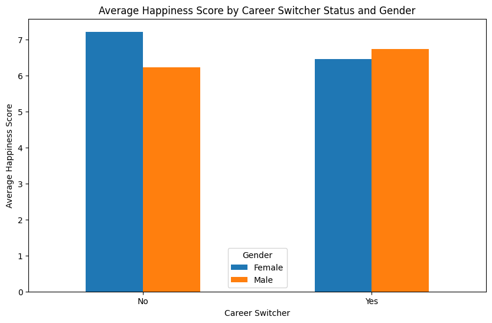

| Gender Career_Switch | Female | Male |
| --- | --- | --- |
| No | 7.222222 | 6.231884 |
| Yes | 6.466667 | 6.736842 |

```python
# Group by 'Career_Switch' and 'Gender' and calculate the mean happiness score
happiness_by_career_switch = df.groupby(['Career_Switch', 'Gender'])['Happiness_WorkLife'].mean().unstack()

happiness_by_career_switch.plot(kind='bar', figsize=(10, 6))
plt.title('Average Happiness Score by Career Switcher Status and Gender')
plt.xlabel('Career Switcher')
plt.ylabel('Average Happiness Score')
plt.xticks(rotation=0)
plt.legend(title='Gender')
plt.show()

happiness_by_career_switch
```

**We can see the data above and assume that switching careet does not effect much on happiness score**

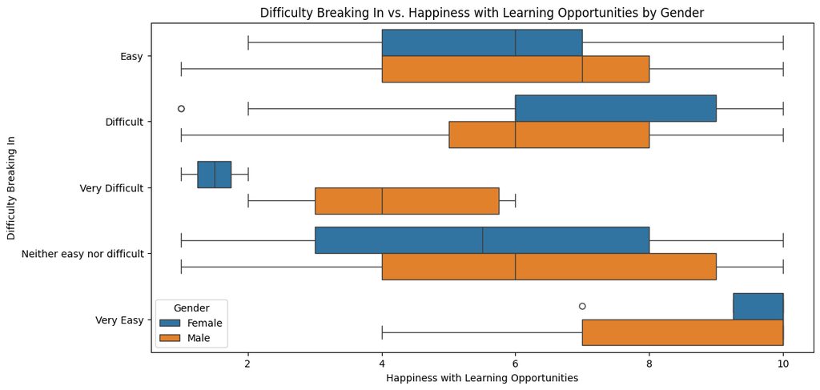

```python
# Create a box plot to compare "Difficulty Breaking In" with "Happiness Learning" and "Happiness Mobility" by gender.
plt.figure(figsize=(12, 6))
sns.boxplot(x='Happiness_Learning', y='Difficulty_Breaking_In', data=df, hue='Gender')
plt.title('Difficulty Breaking In vs. Happiness with Learning Opportunities by Gender')
plt.xlabel('Happiness with Learning Opportunities')
plt.ylabel('Difficulty Breaking In')
plt.show()
```

**At Very Difficult females have less Happiness with Learning Opportunities**

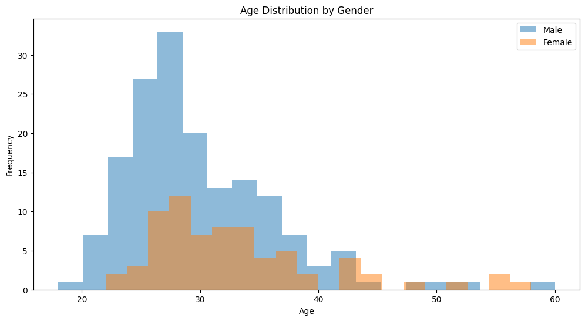

```
        count       mean       std   min   25%   50%    75%   max
Gender
Female   72.0  33.111111  7.694072  22.0  28.0  31.0  36.25  58.0
Male    164.0  29.926829  6.289109  18.0  26.0  28.0  33.00  60.0
```

```python
# Create histograms for age distribution by gender
plt.figure(figsize=(12, 6))
plt.hist(df[df['Gender'] == 'Male']['Age'], bins=20, alpha=0.5, label='Male')
plt.hist(df[df['Gender'] == 'Female']['Age'], bins=20, alpha=0.5, label='Female')
plt.xlabel('Age')
plt.ylabel('Frequency')
plt.title('Age Distribution by Gender')
plt.legend()
plt.show()

# You can further analyze the differences by calculating descriptive statistics
# (mean, median, standard deviation) for age within each gender group.
print(df.groupby('Gender')['Age'].describe())
```

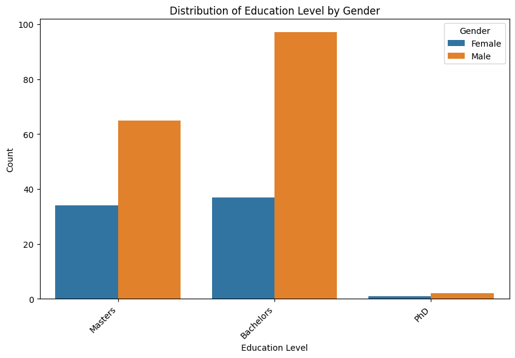

```python
# Create a bar chart to compare "Education Level" across genders
plt.figure(figsize=(10, 6))
sns.countplot(x='Education_Level', data=df, hue='Gender')
plt.title('Distribution of Education Level by Gender')
plt.xlabel('Education Level')
plt.ylabel('Count')
plt.xticks(rotation=45, ha='right')
plt.show()
```

**The Employees who done PhD are very less than the Employees with Masters and Bachelors**

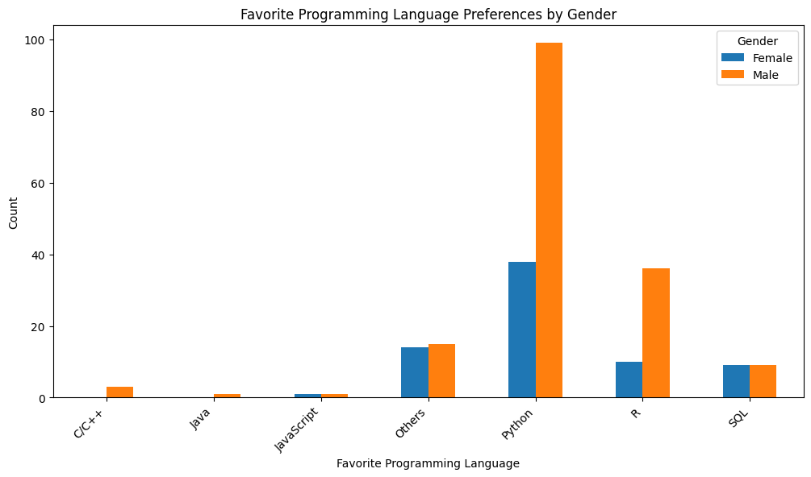

```python
# Group by 'Fav_Language' and 'Gender' and count the occurrences
language_gender_counts = df.groupby(['Fav_Language', 'Gender'])['Gender'].count().unstack()

# Create a bar chart to visualize the counts
language_gender_counts.plot(kind='bar', figsize=(12, 6))
plt.title('Favorite Programming Language Preferences by Gender')
plt.xlabel('Favorite Programming Language')
plt.ylabel('Count')
plt.xticks(rotation=45, ha='right')
plt.legend(title='Gender')
plt.show()
```

**Python is Favorite Programming Language for both male and female employees**

```python
from nbconvert import HTMLExporter
import nbformat
import os # Import the os module

# Load the notebook
notebook_path= '/content/drive/MyDrive/ColabNotebooks/Weeklyassignment.ipynb'
# Update the output path to include a filename
output_html_path = os.path.join('/content/drive/MyDrive/BiweeklyAssignmnet2/html', 'Jagadeeshwari.html')

# The rest of your code remains the same
with open(notebook_path) as f:
  notebook_content=nbformat.read(f, as_version=4)

#convert to HTML
html_exporter= HTMLExporter()
(body , resources) = html_exporter.from_notebook_node(notebook_content)

#save to HTML file
with open(output_html_path, 'w') as f:
  f.write(body)
```

[output not shown]